# Lab 2

#### Name: Rahul Battini

#### Lab Partner: Gautum Kovoor

```python
%matplotlib inline
import numpy as np
import matplotlib
import matplotlib.pyplot as plt
import scipy
from scipy import stats
from scipy.stats import poisson
```

## 1

#### I selected 1 for the average cosmic ray background and 3 for the hypothetical source. As we integrate for more days we just convolve the background value with itself.

```python
x = stats.poisson.pmf(1,3)
x
```

```
0.14936120510359185
```

```python
y = stats.poisson.pmf(1,100)
y
```

```
3.720075976020818e-42
```

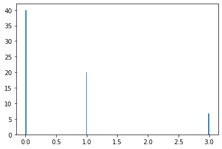

```python
fig, ax = plt.subplots(1, 1)
rv = np.random.poisson(1, 10)
plt.hist(rv, 200, normed=True)
plt.show()
```

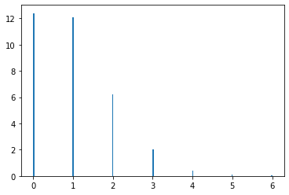

```python
fig, ax = plt.subplots(1, 1)
rv = np.random.poisson(1, 10000)
plt.hist(rv, 200, normed=True)
plt.show()
```

#### When we choose 2 days we get to see 6 gamma rays from our source. This gives us a 2/3 std dev so this is 3 sigma as the background is 1.

## 2.

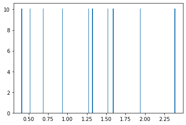

```python
values = plt.hist(np.random.rayleigh(1, 10), bins=200, density=True)
```

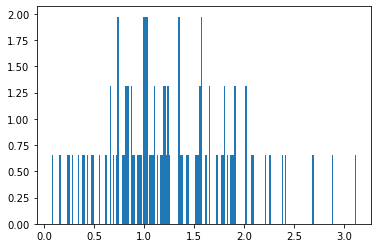

```python
values = plt.hist(np.random.rayleigh(1, 100), bins=200, density=True)
```

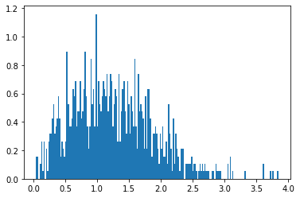

```python
values = plt.hist(np.random.rayleigh(1, 1000), bins=200, density=True)
```

## 3.

#### Lets pick 1 for the background and 6 for the signal. This is significant. Specificallyit is over 5 sigma away which meahs that at these values we can claim a discovery.

#### If we are unsure which pixel that the signal is in then we are much less certain as there effectively is 10000 times the value in the case when we know where it is. In this case the values we have would not even be close to calling it a discovery.

## 4.

#### The signal required for a 5 sigma detection with a background of 1 is 5 when we know where the source is. When we don't we would need a slightly signal to hit 5 sigma in this case 10 would work fine.

#### Brighter signal would be necessary since we don't know where it is. The actual sensitivity penalty is so low because even if something is 10000 times as likely the number of stadard deviations that changes at the far ends isn't too many. If we had less pixels in this case the 5 sigma value would change more as there would be less chance of the background emitting somethign source like.

#### If we have a non-gaussian the sensitivity penalty would be much higher as we wouldn't have as convinient of a distribution